# Plotting inapplicable ancestral states

Thomas Guillerme

2017-02-02

# Before starting

You’ll need `ape` and `RCurl` (for downloading the code) installed. You can install everything by copy/pasting the following (the code checks what’s needed).

```r
if(!require(ape)) install.packages("ape")
if(!require(devtools)) install.packages("devtools")
```

After, you need to load all the code that’s on the `morphy-developement` repo:

```r
source_url("https://raw.githubusercontent.com/mbrazeau/Morphy/development/R/InApp/plot.algorithm.R")
```

```
## SHA-1 hash of file is 3d1fcb2eae768811502fbda18e52ce038c59df61
```

# Plotting the algorithm results

The algorithm is pretty easy, it intakes as arguments: * `tree` the tree in `phylo` format * `character` the character either as a list, a vector of states or a `character` * `passes` the passes to plot (for example `passes = c(1,4)`) only plots the first downpass and the second uppass (it does all the passes though, it’s just visual).

Otherwise it has couple of other graphical options but we don’t care for now.

Here it goes; plotting a silly character on a random tree with 5 taxa (`rtree(5)`) and only the first down and uppass (displayed as `x: y` where `x` is the pass number and `y` the nodal state for that pass:

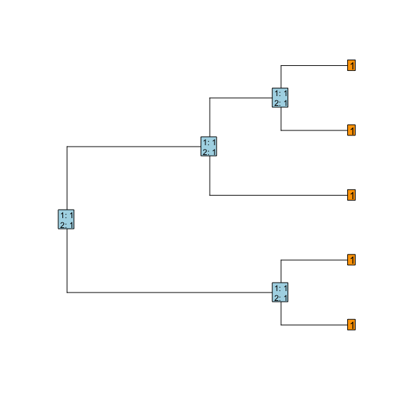

```r
set.seed(1) # for repeatability
tree_5t <- rtree(5)
plot.inapplicable.algorithm(tree_5t, "11111", passes = c(1,2))
```

> Note that you can use the `stree` function (check `?stree`) that allows to generate less random trees (balanced, or ladderised left/right).

For the tree, you can also import your own trees using the `read.tree` or `read.nexus` from `ape` or just by typing the tree manually. Here’s the balance 12 tip tree with the classical Maddison problem:

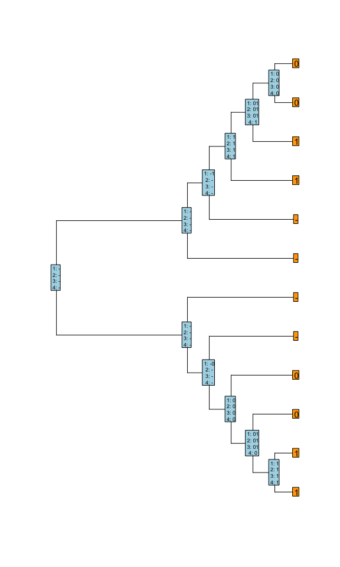

```r
tree_12t <- read.tree(text = "((((((1,2),3),4),5),6),(7,(8,(9,(10,(11,12))))));")
plot.inapplicable.algorithm(tree_12t, "1100----1100")
```

## character argument

The character argument can intake the character as in morphy-like (the easiest) with `-` being inapplicable (of course!) and `?` being all states present. The code transforms the character string (`123-?`) into the normal characters and attributes them to the taxa in the order of appearance:

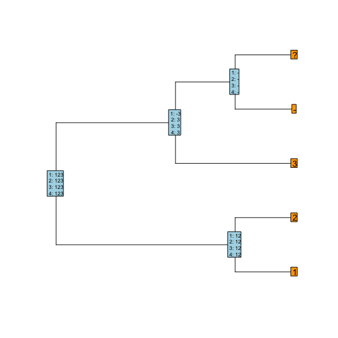

```r
plot.inapplicable.algorithm(tree_5t, "123-?")
```

But you can also input the character as properly read by the code (a `list`) with `-` being `-1` and `?` being all states:

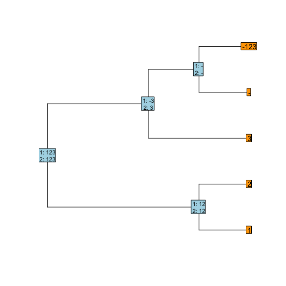

```r
character <- list(c(1),c(2),c(3),c(-1), c(-1,1,2,3))
plot.inapplicable.algorithm(tree_5t, character, passes = c(1,2))
```